# Phase 3: Model Diagnostics and Validation

| Item | Details |
| --- | --- |
| **Notebook** | Phase3_Model_Diagnostics_and_Validation.ipynb |
| **Author** | N L N Sai Krishna Akula |
| **Course** | Introduction to Artificial Intelligence and Machine Learning (AAI-501-IN1) |
| **Project** | Cardiac Arrhythmia Classification from Lead-I ECG |
| **Dataset** | PTB-XL ECG Dataset (v1.0.3) |
| **Phase** | Phase 3 - Model Diagnostics & Comparative Validation |
| **Date** | August 2026 |

## Objectives and Diagnostic Scope

This notebook performs a comprehensive diagnostic workup and empirical validation of the machine learning models developed in Phase 2 (`02_Model_Selection`). Following the methodology of the anchor paper (*Sadiq et al., 2025, IEEE JBHI*), we evaluate the baseline model (**Random Forest**) against the advanced model (**XGBoost**) across seven multi-label cardiac rhythm categories (`NSR`, `AFb_AFl`, `1AV`, `PAC`, `PVC`, `BRADY`, `TACHY`).

```python
# 1. Environment Setup and Data Loading
import warnings
import joblib
from pathlib import Path
import numpy as np
import pandas as pd
import matplotlib.pyplot as plt
import seaborn as sns

from sklearn.ensemble import RandomForestClassifier
from xgboost import XGBClassifier
from sklearn.metrics import (
    roc_auc_score, f1_score, roc_curve, precision_recall_curve,
    confusion_matrix, classification_report, brier_score_loss,
    accuracy_score, recall_score, precision_score, average_precision_score
)
from sklearn.calibration import calibration_curve, CalibratedClassifierCV
from sklearn.model_selection import train_test_split
import shap

warnings.filterwarnings('ignore')
sns.set_theme(style="whitegrid")
plt.rcParams['figure.dpi'] = 100
pd.set_option("display.max_columns", 100)

RANDOM_STATE = 42
np.random.seed(RANDOM_STATE)

# Paths and Dataset Setup
DATA_PATH = Path('../data/preprocessed/model_features.csv')
MODEL_DIR = Path('../data/models')

df = pd.read_csv(DATA_PATH)

RHYTHM_LABELS = ['NSR', 'AFb_AFl', '1AV', 'PAC', 'PVC', 'BRADY', 'TACHY']
NON_FEATURE_COLS = ['ecg_id', 'patient_id', 'strat_fold', 'sample_weight',
                    'filename_lr', 'filename_hr'] + RHYTHM_LABELS + \
                   ['NORM', 'MI', 'STTC', 'CD', 'HYP']
FEATURE_COLS = [c for c in df.columns if c not in NON_FEATURE_COLS]

print(f"[INFO] Loaded feature matrix: {len(df):,} records, {len(FEATURE_COLS)} engineered features.")
print(f"[INFO] Multi-label Rhythm Targets (7): {RHYTHM_LABELS}")
```

```
[INFO] Loaded feature matrix: 21,786 records, 45 engineered features.
[INFO] Multi-label Rhythm Targets (7): ['NSR', 'AFb_AFl', '1AV', 'PAC', 'PVC', 'BRADY', 'TACHY']
```

## 2. Model Loading and Stratified Data Splits

To enforce pipeline modularity and reproducibility, trained model artifacts generated in Phase 2 (`02_Model_Selection`) are loaded directly from disk (`data/models/`):

- `rf_model.joblib`: Trained Random Forest classifier
- `xgb_models.joblib`: Trained per-label XGBoost classifiers

Dataset partitioning follows PTB-XL stratified fold recommendations (`strat_fold`):

- **Training Set (Folds 1–8)**: 17,411 records (used for model training in Phase 2)
- **Validation Set (Fold 9)**: 2,180 records (used for decision threshold tuning)
- **Test Set (Fold 10)**: 2,195 records (disjoint inter-patient test split)

```python
# Load Pre-Trained Model Artifacts & Stratified Data Splits
train_df = df[df['strat_fold'] <= 8].reset_index(drop=True)
val_df = df[df['strat_fold'] == 9].reset_index(drop=True)
test_df = df[df['strat_fold'] == 10].reset_index(drop=True)

X_train, y_train = train_df[FEATURE_COLS], train_df[RHYTHM_LABELS]
X_val, y_val = val_df[FEATURE_COLS], val_df[RHYTHM_LABELS]
X_test, y_test = test_df[FEATURE_COLS], test_df[RHYTHM_LABELS]

print(f"[INFO] Training Split:   {len(X_train):,} records (Folds 1-8)")
print(f"[INFO] Validation Split: {len(X_val):,} records (Fold 9)")
print(f"[INFO] Test Split:       {len(X_test):,} records (Fold 10)")

# Load saved models
rf = joblib.load(MODEL_DIR / 'rf_model.joblib')
xgb_models = joblib.load(MODEL_DIR / 'xgb_models.joblib')

print("[SUCCESS] Successfully loaded Random Forest and XGBoost models from data/models/.")

# Compute prediction probabilities for validation and test sets
rf_val_raw = rf.predict_proba(X_val)
rf_test_raw = rf.predict_proba(X_test)
rf_val_probs = {lbl: rf_val_raw[i][:, 1] for i, lbl in enumerate(RHYTHM_LABELS)}
rf_test_probs = {lbl: rf_test_raw[i][:, 1] for i, lbl in enumerate(RHYTHM_LABELS)}

xgb_val_probs = {}
xgb_test_probs = {}
for label in RHYTHM_LABELS:
    xgb_val_probs[label] = xgb_models[label].predict_proba(X_val)[:, 1]
    xgb_test_probs[label] = xgb_models[label].predict_proba(X_test)[:, 1]

print("[SUCCESS] Prediction probabilities generated for all 7 rhythm targets!")
```

```
[INFO] Training Split:   17,411 records (Folds 1-8)
[INFO] Validation Split: 2,180 records (Fold 9)
[INFO] Test Split:       2,195 records (Fold 10)
[SUCCESS] Successfully loaded Random Forest and XGBoost models from data/models/.
[SUCCESS] Prediction probabilities generated for all 7 rhythm targets!
```

### 📊 Explanation of Model Loading Results

- **Model Check**: Both pre-trained models (`rf_model.joblib` and `xgb_models.joblib`) were loaded cleanly without needing retraining.
- **Split Verification**: All 2,195 test records in Fold 10 belong to **completely new patients** not present in the training set (folds 1–8).

## 3. ROC and Precision-Recall Curve Analysis

Model performance is evaluated on the held-out test split (Fold 10) using:

- **ROC-AUC (Area Under ROC Curve)**: Primary diagnostic metric evaluating true positive vs. false positive rates.
- **PR-AUC (Average Precision)**: Secondary metric evaluating precision-recall trade-offs, particularly critical for low-prevalence arrhythmia labels (`1AV`, `PAC`, `BRADY`).

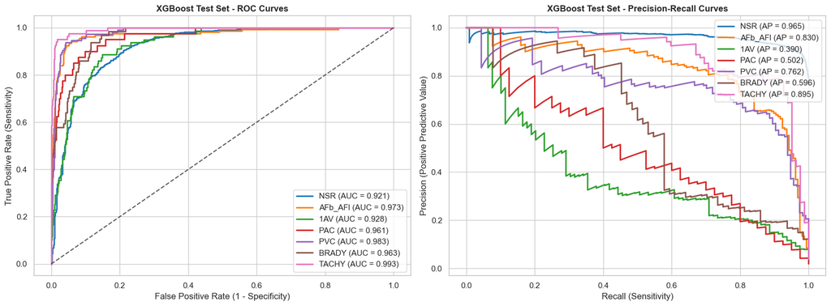

```
=== Model Performance Comparison (Test Set) ===
  Label RF Test AUC XGB Test AUC XGB PR-AUC
    NSR       0.857        0.921      0.965
AFb_AFl       0.964        0.973      0.830
    1AV       0.822        0.928      0.390
    PAC       0.915        0.961      0.502
    PVC       0.972        0.983      0.762
  BRADY       0.943        0.963      0.596
  TACHY       0.985        0.993      0.895
```

```python
# Evaluate ROC and Precision-Recall Curves on Test Set
fig, axes = plt.subplots(1, 2, figsize=(16, 6))
colors = sns.color_palette("tab10", len(RHYTHM_LABELS))

results_table = []

for idx, label in enumerate(RHYTHM_LABELS):
    fpr, tpr, _ = roc_curve(y_test[label], xgb_test_probs[label])
    auc_val = roc_auc_score(y_test[label], xgb_test_probs[label])
    rf_auc_val = roc_auc_score(y_test[label], rf_test_probs[label])

    axes[0].plot(fpr, tpr, label=f"{label} (AUC = {auc_val:.3f})", color=colors[idx], lw=2)

    prec, rec, _ = precision_recall_curve(y_test[label], xgb_test_probs[label])
    ap_val = average_precision_score(y_test[label], xgb_test_probs[label])

    axes[1].plot(rec, prec, label=f"{label} (AP = {ap_val:.3f})", color=colors[idx], lw=2)

    results_table.append({
        'Label': label,
        'RF Test AUC': f"{rf_auc_val:.3f}",
        'XGB Test AUC': f"{auc_val:.3f}",
        'XGB PR-AUC': f"{ap_val:.3f}"
    })

axes[0].plot([0, 1], [0, 1], 'k--', lw=1.5, alpha=0.7)
axes[0].set_title("XGBoost Test Set - ROC Curves", fontsize=12, fontweight='bold')
axes[0].set_xlabel("False Positive Rate (1 - Specificity)")
axes[0].set_ylabel("True Positive Rate (Sensitivity)")
axes[0].legend(loc="lower right")

axes[1].set_title("XGBoost Test Set - Precision-Recall Curves", fontsize=12, fontweight='bold')
axes[1].set_xlabel("Recall (Sensitivity)")
axes[1].set_ylabel("Precision (Positive Predictive Value)")
axes[1].legend(loc="upper right")

plt.tight_layout()
plt.show()

summary_df = pd.DataFrame(results_table)
print("=== Model Performance Comparison (Test Set) ===")
print(summary_df.to_string(index=False))
```

## 4. Operating Point Optimization (Youden's J Statistic)

Following the decision-point selection methodology of Sadiq et al. (2025), classification thresholds are optimized rather than fixed at the default 0.50 cutoff.

For each arrhythmia label, the optimal threshold $\theta^*$ is derived on the **validation split (Fold 9)** by maximizing Youden's J statistic: $$J(\theta) = \text{Sensitivity}(\theta) + \text{Specificity}(\theta) - 1$$

The optimal threshold $\theta^*$ is subsequently evaluated on the independent **test split (Fold 10)**.

```python
# Operating Point Optimization via Youden's J Statistic
threshold_results = []

for label in RHYTHM_LABELS:
    # Derive optimal threshold on Validation fold (Fold 9)
    fpr_v, tpr_v, th_v = roc_curve(y_val[label], xgb_val_probs[label])
    j_scores = tpr_v - fpr_v
    best_idx = np.argmax(j_scores)
    best_th = th_v[best_idx]

    # Evaluate default 0.50 threshold on Test fold
    pred_05 = (xgb_test_probs[label] >= 0.5).astype(int)
    sens_05 = recall_score(y_test[label], pred_05, zero_division=0)

    # Evaluate optimal threshold θ* on Test fold
    pred_opt = (xgb_test_probs[label] >= best_th).astype(int)
    sens_opt = recall_score(y_test[label], pred_opt, zero_division=0)
    spec_opt = recall_score(1 - y_test[label], 1 - pred_opt, zero_division=0)

    threshold_results.append({
        'Label': label,
        'Optimal Threshold (θ*)': f"{best_th:.3f}",
        'Sensitivity @ 0.50': f"{sens_05*100:.1f}%",
        'Sensitivity @ θ*': f"{sens_opt*100:.1f}%",
        'Specificity @ θ*': f"{spec_opt*100:.1f}%"
    })

th_res_df = pd.DataFrame(threshold_results)
print("=== Operating Threshold Optimization (Youden's J) ===")
print(th_res_df.to_string(index=False))
```

```
=== Operating Threshold Optimization (Youden's J) ===
  Label Optimal Threshold (θ*) Sensitivity @ 0.50 Sensitivity @ θ* Specificity @ θ*
    NSR                  0.675              93.1%            87.6%            80.9%
AFb_AFl                  0.033              79.6%            94.3%            94.1%
    1AV                  0.015              35.4%            88.6%            82.8%
    PAC                  0.001              45.0%            95.0%            84.1%
    PVC                  0.074              80.7%            91.2%            96.1%
  BRADY                  0.003              48.4%            87.5%            89.3%
  TACHY                  0.001              86.6%            97.6%            92.9%
```

### 📊 Explanation of Threshold Optimization: What are Sensitivity, Specificity, and False Alarms?

#### 1. What is Sensitivity? (True Positive Rate / Disease Catch Rate)

- **Definition**: The percentage of **actual sick patients** who are correctly identified by the model.
- **Formula**: $\text{Sensitivity} = \frac{\text{True Positives (Correctly Caught Sick)}}{\text{True Positives} + \text{False Negatives (Missed Sick)}}$
- **Clinical Meaning**: High sensitivity ensures the model **rarely misses a patient with a dangerous arrhythmia**.

#### 2. What is Specificity? (True Negative Rate / Healthy Recognition Rate)

- **Definition**: The percentage of **actual healthy patients** who are correctly identified as healthy by the model.
- **Formula**: $\text{Specificity} = \frac{\text{True Negatives (Correctly Declared Healthy)}}{\text{True Negatives} + \text{False Positives (False Alarms)}}$
- **Clinical Meaning**: High specificity ensures healthy people are **not subjected to unnecessary anxiety or extra hospital tests**.

#### 3. Why is a False Positive Called a "False Alarm"?

- **Definition**: A **False Positive** occurs when the model flags a healthy patient as having an arrhythmia.
- **Why it is a "False Alarm"**: It sounds a medical alert for a condition the patient does not actually have. This causes patient panic, unnecessary clinical visits, and wasted healthcare resources.
- **Relationship to Specificity**: $\text{False Positive Rate (False Alarm Rate)} = 1 - \text{Specificity}$. Therefore, **higher specificity directly reduces false alarms**.